# ML_Assignment

Alex Perez Nava

1/7/2019

## Overview

Using devices such as Jawbone Up, Nike FuelBand, and Fitbit, it is now possible to collect a large amount of data about personal activity relatively inexpensively. The aim of this project is to predict the manner in which participants perform a barbell lift. The data comes from http://groupware.les.inf.puc-rio.br/har wherein 6 participants were asked to perform the same set of exercises correctly and incorrectly with accelerometers placed on the belt, forearm, arm, and dumbbell.

## Background

“Six young health participants were asked to perform one set of 10 repetitions of the Unilateral Dumbbell Biceps Curl in five different fashions: exactly according to the specification (Class A), throwing the elbows to the front (Class B), lifting the dumbbell only halfway (Class C), lowering the dumbbell only halfway (Class D) and throwing the hips to the front (Class E).

Class A corresponds to the specified execution of the exercise, while the other 4 classes correspond to common mistakes. Participants were supervised by an experienced weight lifter to make sure the execution complied to the manner they were supposed to simulate. The exercises were performed by six male participants aged between 20-28 years, with little weight lifting experience. We made sure that all participants could easily simulate the mistakes in a safe and controlled manner by using a relatively light dumbbell (1.25kg)."

## Get and process data

Get data set from the URL below. The training data set is partitioned in two to create a Training set (70% of the data) for the modeling process and a Test set (30%) for the validations.

The training data for this project are available here:

https://d396qusza40orc.cloudfront.net/predmachlearn/pml-training.csv

The test data are available here:

https://d396qusza40orc.cloudfront.net/predmachlearn/pml-testing.csv

The data for this project come from http://groupware.les.inf.puc-rio.br/har. Full source:

Velloso, E.; Bulling, A.; Gellersen, H.; Ugulino, W.; Fuks, H. “Qualitative Activity Recognition of Weight Lifting Exercises. Proceedings of 4th International Conference in Cooperation with SIGCHI (Augmented Human ’13)”. Stuttgart, Germany: ACM SIGCHI, 2013.

# Set the URL for the download

```r
UrlTrain <- "http://d396qusza40orc.cloudfront.net/predmachlearn/pml-training.csv"
UrlTest  <- "http://d396qusza40orc.cloudfront.net/predmachlearn/pml-testing.csv"
```

# Download the datasets

```r
training <- read.csv(url(UrlTrain))
testing  <- read.csv(url(UrlTest))
```

# Create a partition with the training data set

```r
inTrain  <- createDataPartition(training$classe, p=0.7, list=FALSE)
TrainSet <- training[inTrain, ]
TestSet  <- training[-inTrain, ]
dim(TrainSet)
```

```
## [1] 13737   160
```

```r
dim(TestSet)
```

```
## [1] 5885  160
```

Created data sets have 160 variables. Clean data set removing NA’s. Near Zero variance (NZV) variables and ID.

# Remove variables with Nearly Zero Variance

```r
NZV <- nearZeroVar(TrainSet)
TrainSet <- TrainSet[, -NZV]
TestSet  <- TestSet[, -NZV]
dim(TrainSet)
```

```
## [1] 13737   101
```

```r
dim(TestSet)
```

```
## [1] 5885  101
```

# Remove variables that are mostly NA

[output not shown]

```r
dim(TestSet)
```

```
## [1] 5885   59
```

# Remove identification only variables (columns 1 to 5)

[output not shown]

```r
dim(TestSet)
```

```
## [1] 5885   54
```

The data sets for the analysis have now 54 variables as a result of the cleaning process.

```r
names(TrainSet)
```

```
##  [1] "num_window"           "roll_belt"            "pitch_belt"
##  [4] "yaw_belt"             "total_accel_belt"     "gyros_belt_x"
##  [7] "gyros_belt_y"         "gyros_belt_z"         "accel_belt_x"
## [10] "accel_belt_y"         "accel_belt_z"         "magnet_belt_x"
## [13] "magnet_belt_y"        "magnet_belt_z"        "roll_arm"
## [16] "pitch_arm"            "yaw_arm"              "total_accel_arm"
## [19] "gyros_arm_x"          "gyros_arm_y"          "gyros_arm_z"
## [22] "accel_arm_x"          "accel_arm_y"          "accel_arm_z"
## [25] "magnet_arm_x"         "magnet_arm_y"         "magnet_arm_z"
## [28] "roll_dumbbell"        "pitch_dumbbell"       "yaw_dumbbell"
## [31] "total_accel_dumbbell" "gyros_dumbbell_x"     "gyros_dumbbell_y"
## [34] "gyros_dumbbell_z"     "accel_dumbbell_x"     "accel_dumbbell_y"
## [37] "accel_dumbbell_z"     "magnet_dumbbell_x"    "magnet_dumbbell_y"
## [40] "magnet_dumbbell_z"    "roll_forearm"         "pitch_forearm"
## [43] "yaw_forearm"          "total_accel_forearm"  "gyros_forearm_x"
## [46] "gyros_forearm_y"      "gyros_forearm_z"      "accel_forearm_x"
## [49] "accel_forearm_y"      "accel_forearm_z"      "magnet_forearm_x"
## [52] "magnet_forearm_y"     "magnet_forearm_z"     "classe"
```

## Correlation analysis

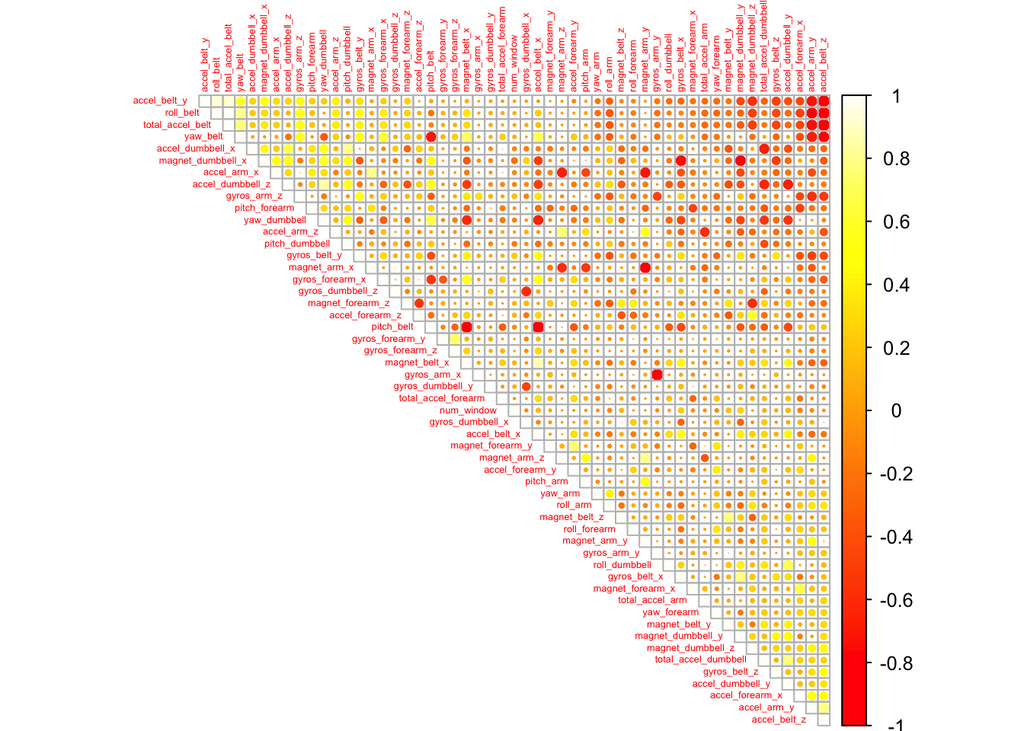

Positive correlation are shown in yellow circles and negative in red. Color intensity and size of the circle are proportional to the correlation coefficients.

## Prediction Model

We want to compare methods in order to identify the one with higher accuracy then applied it to the Test data set. The selected method will be used for the quiz predictions. The methods are: Random Forests, Decision Tree and Generalized Boosted Model. Look at the Confusion Matrix of each method.

## I.-Random Forest

model fit

```r
set.seed(12345)
controlRF <- trainControl(method="cv", number=3, verboseIter=FALSE)
modFitRandForest <- train(classe ~ ., data=TrainSet, method="rf",trControl=controlRF)
modFitRandForest$finalModel
```

```
##
## Call:
##  randomForest(x = x, y = y, mtry = param$mtry)
##                Type of random forest: classification
##                      Number of trees: 500
## No. of variables tried at each split: 27
##
##         OOB estimate of  error rate: 0.18%
## Confusion matrix:
##      A    B    C    D    E  class.error
## A 3905    1    0    0    0 0.0002560164
## B    3 2652    3    0    0 0.0022573363
## C    0    5 2391    0    0 0.0020868114
## D    0    0    7 2244    1 0.0035523979
## E    0    0    0    5 2520 0.0019801980
```

# Prediction on Test dataset

```r
predictRandForest <- predict(modFitRandForest, newdata=TestSet)
confMatRandForest <- confusionMatrix(predictRandForest, TestSet$classe)
confMatRandForest
```

```
## Confusion Matrix and Statistics
##
##           Reference
## Prediction    A    B    C    D    E
##          A 1673    1    0    0    0
##          B    0 1137    0    0    0
##          C    0    1 1023    4    0
##          D    0    0    3  960    0
##          E    1    0    0    0 1082
##
## Overall Statistics
##
##                Accuracy : 0.9983
##                  95% CI : (0.9969, 0.9992)
##     No Information Rate : 0.2845
##     P-Value [Acc > NIR] : < 2.2e-16
##
##                   Kappa : 0.9979
##
##  Mcnemar's Test P-Value : NA
##
## Statistics by Class:
##
##                      Class: A Class: B Class: C Class: D Class: E
## Sensitivity            0.9994   0.9982   0.9971   0.9959   1.0000
## Specificity            0.9998   1.0000   0.9990   0.9994   0.9998
## Pos Pred Value         0.9994   1.0000   0.9951   0.9969   0.9991
## Neg Pred Value         0.9998   0.9996   0.9994   0.9992   1.0000
## Prevalence             0.2845   0.1935   0.1743   0.1638   0.1839
## Detection Rate         0.2843   0.1932   0.1738   0.1631   0.1839
## Detection Prevalence   0.2845   0.1932   0.1747   0.1636   0.1840
## Balanced Accuracy      0.9996   0.9991   0.9980   0.9976   0.9999
```

# Plot matrix results

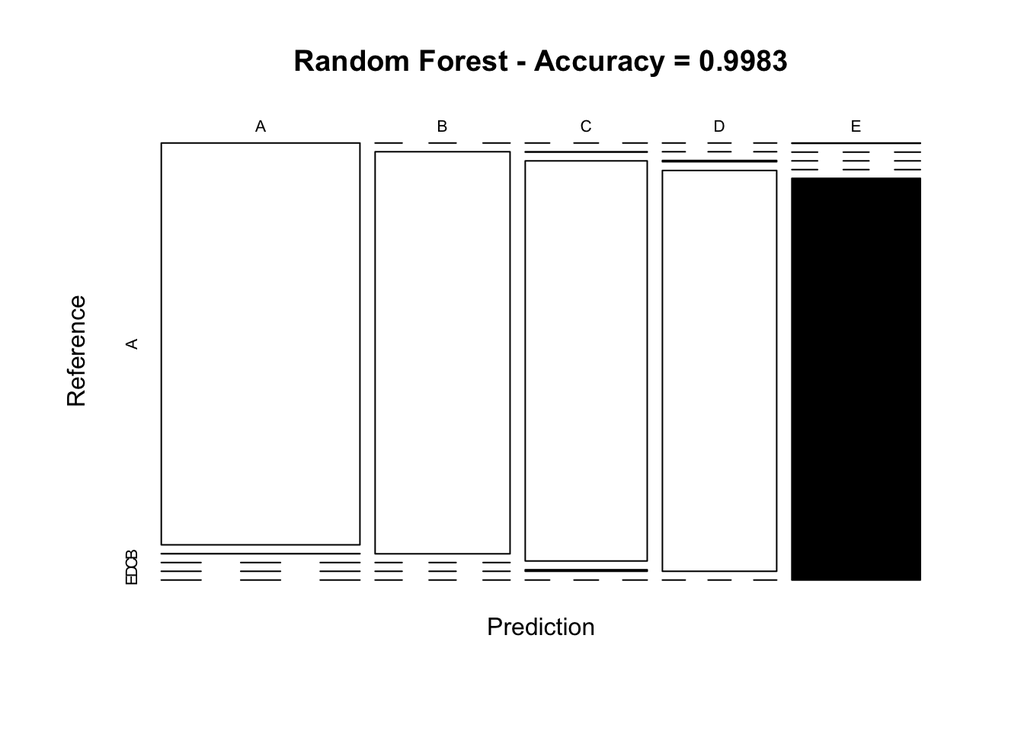

## II.-Decision Trees

model fit

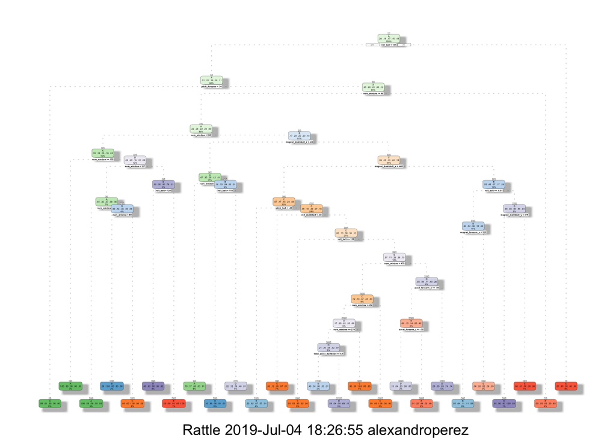

```r
set.seed(12345)
modFitDecTree <- rpart(classe ~ ., data=TrainSet, method="class")
fancyRpartPlot(modFitDecTree)
```

# Prediction on Test data set

```r
predictDecTree <- predict(modFitDecTree, newdata=TestSet, type="class")
confMatDecTree <- confusionMatrix(predictDecTree, TestSet$classe)
confMatDecTree
```

```
## Confusion Matrix and Statistics
##
##           Reference
## Prediction    A    B    C    D    E
##          A 1429   78    1   25    7
##          B  133  866   51   97   59
##          C    0   64  846   37    3
##          D   99   63  115  744   68
##          E   13   68   13   61  945
##
## Overall Statistics
##
##                Accuracy : 0.8207
##                  95% CI : (0.8107, 0.8305)
##     No Information Rate : 0.2845
##     P-Value [Acc > NIR] : < 2.2e-16
##
##                   Kappa : 0.774
##
##  Mcnemar's Test P-Value : < 2.2e-16
##
## Statistics by Class:
##
##                      Class: A Class: B Class: C Class: D Class: E
## Sensitivity            0.8536   0.7603   0.8246   0.7718   0.8734
## Specificity            0.9736   0.9284   0.9786   0.9299   0.9677
## Pos Pred Value         0.9279   0.7181   0.8905   0.6832   0.8591
## Neg Pred Value         0.9436   0.9417   0.9635   0.9541   0.9714
## Prevalence             0.2845   0.1935   0.1743   0.1638   0.1839
## Detection Rate         0.2428   0.1472   0.1438   0.1264   0.1606
## Detection Prevalence   0.2617   0.2049   0.1614   0.1850   0.1869
## Balanced Accuracy      0.9136   0.8443   0.9016   0.8508   0.9206
```

# Plot matrix results

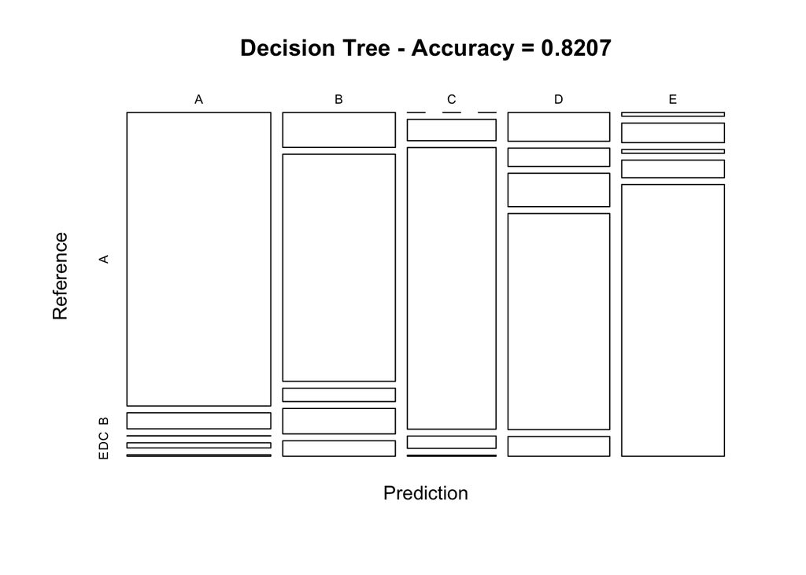

## III.-Generalized Boosted Model

model fit

```r
set.seed(12345)
controlGBM <- trainControl(method = "repeatedcv", number = 5, repeats = 1)
modFitGBM  <- train(classe ~ ., data=TrainSet, method = "gbm",trControl = controlGBM, verbose = FALSE)
modFitGBM$finalModel
```

```
## A gradient boosted model with multinomial loss function.
## 150 iterations were performed.
## There were 53 predictors of which 53 had non-zero influence.
```

# Prediction on Test data set

```r
predictGBM <- predict(modFitGBM, newdata=TestSet)
confMatGBM <- confusionMatrix(predictGBM, TestSet$classe)
confMatGBM
```

```
## Confusion Matrix and Statistics
##
##           Reference
## Prediction    A    B    C    D    E
##          A 1669   17    0    1    0
##          B    5 1114    7    5    6
##          C    0    8 1016   15    3
##          D    0    0    3  942    9
##          E    0    0    0    1 1064
##
## Overall Statistics
##
##                Accuracy : 0.9864
##                  95% CI : (0.9831, 0.9892)
##     No Information Rate : 0.2845
##     P-Value [Acc > NIR] : < 2.2e-16
##
##                   Kappa : 0.9828
##
##  Mcnemar's Test P-Value : NA
##
## Statistics by Class:
##
##                      Class: A Class: B Class: C Class: D Class: E
## Sensitivity            0.9970   0.9781   0.9903   0.9772   0.9834
## Specificity            0.9957   0.9952   0.9946   0.9976   0.9998
## Pos Pred Value         0.9893   0.9798   0.9750   0.9874   0.9991
## Neg Pred Value         0.9988   0.9947   0.9979   0.9955   0.9963
## Prevalence             0.2845   0.1935   0.1743   0.1638   0.1839
## Detection Rate         0.2836   0.1893   0.1726   0.1601   0.1808
## Detection Prevalence   0.2867   0.1932   0.1771   0.1621   0.1810
## Balanced Accuracy      0.9964   0.9866   0.9925   0.9874   0.9916
```

# Plot matrix results

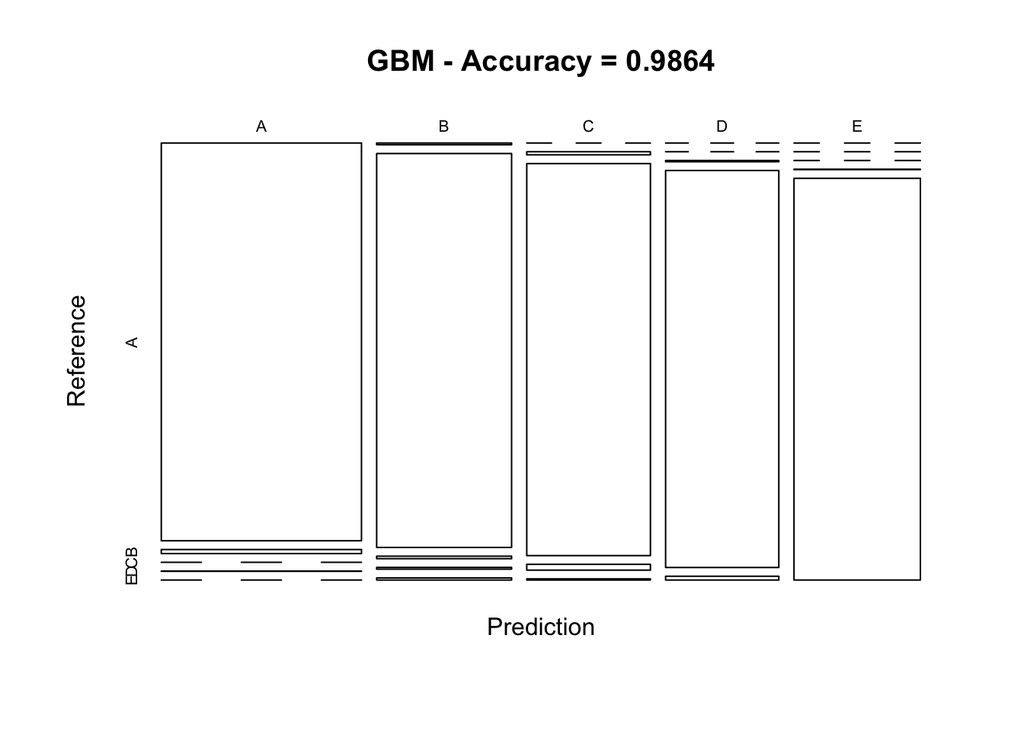

Random Forest shows the highest accuracy.

In conclusion, the Random Forest model will be applied to predict the 20 quiz results.